# sparklyr example

Nicholas Horton (nhorton@amherst.edu)

October 30, 2020

The `sparklyr` package facilitates access to Spark clusters from within RStudio at hadoop2-rstudio.amherst.edu. See http://spark.rstudio.com for details of the implementation.

```r
install.packages("devtools")    # these are already installed on the server
devtools::install_github("rstudio/sparklyr")
```

```r
library(sparklyr)
spark_install(version = "1.6.1")  # once only
```

```r
library(sparklyr)
sc <- spark_connect(master = "yarn-client")
spark_version(sc)
```

```
## [1] '1.6.1'
```

The returned Spark connection (sc) provides a remote dplyr data source to the Spark cluster.

For more information on connecting to remote Spark clusters see the Deployment section.

#### Reading Data

You can copy R data frames into Spark using the copy_to function (more typically though you’ll read data within the Spark cluster using the spark_read family of functions). For the examples below we’ll copy some datasets from R into Spark (note that you may need to install the nycflights13 and Lahman packages in order to execute this code):

```r
iris_tbl <- copy_to(sc, iris)
flights_tbl <- copy_to(sc, nycflights13::flights, "flights")
batting_tbl <- copy_to(sc, Lahman::Batting, "batting")
```

You can list all of the available tables (including those that were already pre-loaded within the cluster) using the dplyr src_tbls function:

```r
src_tbls(sc)
```

```
## [1] "airlines"         "airports"         "batting"          "flights"
## [5] "flights_small"    "flights_wrangled" "iris"
```

#### Using dplyr

We can new use all of the available dplyr verbs against the tables within the cluster. Here’s a simple filtering example:

```r
# filter by departure delay
flights_tbl %>% filter(dep_delay == 2)
```

```
## # Source: spark<?> [?? x 19]
##     year month   day dep_time sched_dep_time dep_delay arr_time sched_arr_time
##    <int> <int> <int>    <int>          <int>     <dbl>    <int>          <int>
##  1  2013     1     1      517            515         2      830            819
##  2  2013     1     1      542            540         2      923            850
##  3  2013     1     1      702            700         2     1058           1014
##  4  2013     1     1      715            713         2      911            850
##  5  2013     1     1      752            750         2     1025           1029
##  6  2013     1     1      917            915         2     1206           1211
##  7  2013     1     1      932            930         2     1219           1225
##  8  2013     1     1     1028           1026         2     1350           1339
##  9  2013     1     1     1042           1040         2     1325           1326
## 10  2013     1     1     1231           1229         2     1523           1529
## # … with more rows, and 11 more variables: arr_delay <dbl>, carrier <chr>,
## #   flight <int>, tailnum <chr>, origin <chr>, dest <chr>, air_time <dbl>,
## #   distance <dbl>, hour <dbl>, minute <dbl>, time_hour <dttm>
```

#### Intro to accessing Spark via dplyr

The introduction to dplyr provides additional dplyr examples you can try. For example, consider the last example from the tutorial which plots data on flight delays:

```r
delay <- flights_tbl %>%
  group_by(tailnum) %>%
  summarise(count = n(), dist = mean(distance, na.rm = TRUE), delay = mean(arr_delay)) %>%
  filter(count > 20, dist < 2000, !is.na(delay)) %>%
  collect
```

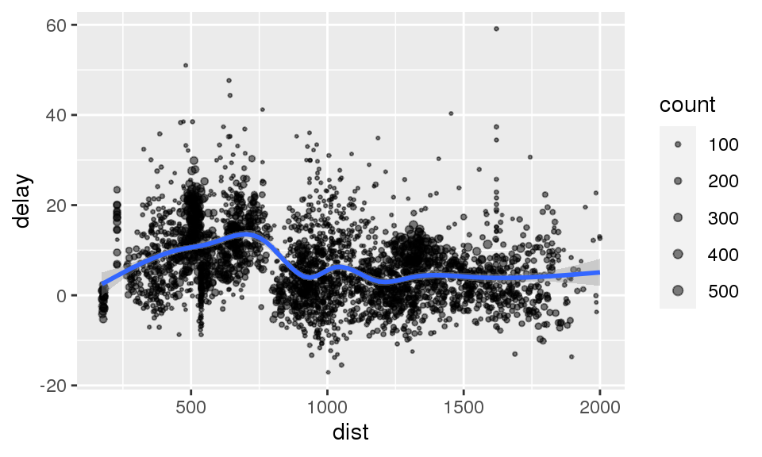

```r
# plot delays
library(ggplot2)
ggplot(delay, aes(dist, delay)) +
  geom_point(aes(size = count), alpha = 1/2) +
  geom_smooth() +
  scale_size_area(max_size = 2)
```

#### Window Functions

dplyr window functions are also supported, for example:

```r
batting_tbl %>%
  select(playerID, yearID, teamID, G, AB:H) %>%
  arrange(playerID, yearID, teamID) %>%
  group_by(playerID) %>%
  filter(min_rank(desc(H)) <= 2 & H > 0)
```

```
## # Source:     spark<?> [?? x 7]
## # Groups:     playerID
## # Ordered by: playerID, yearID, teamID
##    playerID  yearID teamID     G    AB     R     H
##    <chr>      <int> <chr>  <int> <int> <int> <int>
##  1 anderal01   1941 PIT       70   223    32    48
##  2 anderal01   1942 PIT       54   166    24    45
##  3 balesco01   2008 WAS       15    15     1     3
##  4 balesco01   2009 WAS        7     8     0     1
##  5 bandoch01   1986 CLE       92   254    28    68
##  6 bandoch01   1984 CLE       75   220    38    64
##  7 bedelho01   1962 ML1       58   138    15    27
##  8 bedelho01   1968 PHI        9     7     0     1
##  9 biittla01   1977 CHN      138   493    74   147
## 10 biittla01   1975 MON      121   346    34   109
## # … with more rows
```

For additional documentation on using dplyr with Spark see the dplyr section.

#### Using MLlib

You can orchestrate machine learning algorithms in a Spark cluster via the MLlib functions in sparklyr. These functions connect to a set of high-level APIs built on top of DataFrames that help you create and tune machine learning workflows.

In this example we’ll use `ml_linear_regression` to fit a linear regression model. We’ll use the built-in mtcars dataset, and see if we can predict a car’s fuel consumption (mpg) based on its weight (wt), and the number of cylinders the engine contains (cyl). We’ll assume in each case that the relationship between mpg and each of our features is linear.

```r
# copy mtcars into spark
mtcars_tbl <- copy_to(sc, mtcars)

# transform our data set, and then partition into 'training', 'test'
partitions <- mtcars_tbl %>%
  filter(hp >= 100) %>%
  mutate(cyl8 = cyl == 8) %>%
  sdf_random_split(training = 0.5, test = 0.5, seed = 1099)

# fit a linear model to the training dataset
fit <- partitions$training %>%
  ml_linear_regression(response = "mpg", features = c("wt", "cyl"))
```

For linear regression models produced by Spark, we can use `summary()` to learn a bit more about the quality of our fit, and the statistical significance of each of our predictors.

```r
summary(fit)
```

```
## Deviance Residuals:
##    Min     1Q Median     3Q    Max
## -1.752 -1.134 -0.499  1.296  2.282
##
## Coefficients:
## (Intercept)          wt         cyl
##   33.499452   -2.818463   -0.923187
##
## R-Squared: 0.8274
## Root Mean Squared Error: 1.422
```

Spark machine learning supports a wide array of algorithms and feature transformations and as illustrated above it’s easy to chain these functions together with dplyr pipelines. To learn more see the MLlib section.

#### Extensions

The facilities used internally by sparklyr for its dplyr and MLlib interfaces are available to extension packages via the sparkapi package. Since Spark is a general purpose cluster computing system there are many potential applications for extensions (e.g. interfaces to custom machine learning pipelines, interfaces to 3rd party Spark packages, etc.).

To learn more about creating extensions see the Extensions section.

```r
spark_disconnect(sc)
```

#### RStudio IDE

The latest RStudio Preview Release of the RStudio IDE includes integrated support for Spark and the sparklyr package, including tools for creating and managing Spark connections.

Once you’ve installed the sparklyr package, you should find a new Spark pane within the IDE. This pane includes a New Connection dialog which can be used to make connections to local or remote Spark instances.

Once you’ve connected to Spark you’ll be able to browse the tables contained within the Spark cluster. The Spark DataFrame preview uses the standard RStudio data viewer. The RStudio IDE features for sparklyr are available now as part of the RStudio Preview Release.